# Design Declaration

Punish or Reconcile? Target Framing, Performance Cues, and Authoritarian Legitimation through Repression

Authors

Daniel Kuhlen

Giovanna Lapresa

Jorge Zavala

Published

February 26, 2026

# Design

We want to implement a two-step vignette design. First, respondents are surveyed on pre-treatment variables (likely we can look for synergies in variables with other teams). Within our experiment, they are then divided into four equal vignettes along the dimensions *Restorative Justice* / *Punitive Justice* and *Threat Frame* / *No Threat Frame* and asked the first set of outcome questions. Following this, subsamples are assigned to a performance / no performance vignette and are asked the outcome battery again.

This design allows us to (1) test (Lachapelle 2022) triadic theory on repression; and (2) advance the theory with a performance dimension (Przeworski 2023). In total, we expect the design to take up 4–5 minutes maximum. Figure 1 illustrates the experiment design.

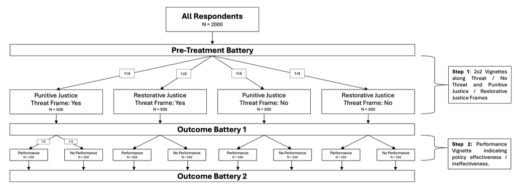

Figure 1: Experiment Design